# 5260_Final_Boucaud_Le

Final - R code

Gabe Boucaud and Kimberly Le

## Load libraries

```r
# Load packages
library(lpSolveAPI)
`%>%` <- magrittr::`%>%`
library(knitr)
library(kableExtra)
library(igraph)
library(tidyverse)
library(MASS)
library(queueing)
```

## Read data file

```r
rm(list = ls(all = TRUE))

# read in dataset
data <- read.csv('data.csv', sep= ",", header = TRUE, fileEncoding="UTF-8-BOM")
```

## Proposal 1

```r
#This model has choice variables that are binary
p1 <- make.lp(0, 35)
lp.control(p1, sense = "max")

# Set penalty variable to force either-or of constraint


obj_fn <- c(rep(1, 34), 0)
set.objfn(p1, obj_fn)

# Add constraints

# Cost
add.constraint(p1, c(data$Price, 0), "<=", 4000000)

# Valentino's requests
# One collage
add.constraint(p1, c(0, 0,  0,  0,  0,  0,
                     0, 0,  1,  0,  0,  0,
                     0, 0,  0,  1,  0,  0,
                     0, 0,  0,  0,  0,  0,
                     0, 0,  0,  0,  1,  1,
                     0, 0,  0,  0, 0), "=", 1)

# At least one wire mesh sculpture displayed if a computer-generated drawing is displayed
add.constraint(p1, c(1, 1,  1,  -1, -1, 0,
                     0, 0,  0,  0,  0,  0,
                     0, 0,  0,  0,  0,  0,
                     0, 0,  0,  0,  0,  0,
                     0, 0,  0,  0,  0,  0,
                     0, 0,  0,  0, 0), "<=", 0)

# At least one computer-generated drawing displayed if a wire mesh sculpture is displayed
add.constraint(p1, c(-1, -1, -1, 1, 1,  0,
                     0, 0,  0,  0,  0,  0,
                     0, 0,  0,  0,  0,  0,
                     0, 0,  0,  0,  0,  0,
                     0, 0,  0,  0,  0,  0,
                     0, 0,  0,  0, 0), "<=", 0)

# At least one photo-realistic painting
add.constraint(p1, c(0, 0,  0,  0,  0,  0,
                     0, 0,  0,  0,  0,  0,
                     0, 1,  1,  0,  0,  0,
                     1, 0,  0,  0,  0,  0,
                     0, 0,  0,  0,  0,  0,
                     0, 0,  0,  0, 0), ">=", 1)

# At least one cubist painting
add.constraint(p1, c(0, 0,  0,  0,  0,  0,
                     0, 0,  0,  0,  0,  0,
                     0, 0,  0,  0,  0,  0,
                     0, 1,  0,  0,  0,  0,
                     0, 0,  1,  1,  0,  0,
                     0, 0,  0,  0, 0), ">=", 1)

# At least one expressionist painting
add.constraint(p1, c(0, 0,  0,  0,  0,  0,
                     0, 0,  0,  0,  0,  0,
                     0, 0,  0,  0,  0,  0,
                     0, 0,  1,  0,  0,  0,
                     0, 0,  0,  0,  0,  0,
                     0, 0,  0,  0, 0), ">=", 1)

# At least one watercolor painting
add.constraint(p1, c(0, 0,  0,  0,  0,  0,
                     0, 0,  0,  1,  1,  0,
                     0, 0,  0,  0,  0,  0,
                     0, 0,  0,  0,  0,  0,
                     0, 0,  0,  0,  0,  0,
                     1, 1,  1,  1, 0), ">=", 1)

# At least one oil painting
add.constraint(p1, c(0, 0,  0,  0,  0,  0,
                     0, 0,  0,  0,  0,  1,
                     1, 0,  0,  0,  0,  0,
                     0, 0,  0,  1,  1,  0,
                     0, 1,  0,  0,  0,  0,
                     0, 0,  0,  0, 0), ">=", 1)

# Number of paintings to be no greater than three times the number of other art forms
add.constraint(p1, c(3, 3,  3,  3,  3,  3,
                     3, 3,  3,  -1, -1, -1,
                     -1,    -1, -1, 3,  3,  3,
                     -1,    -1, -1, -1, -1, 3,
                     3, -1, -1, -1, 3,  3,
                     -1, -1,-1, -1, 0), ">=", 0)

# All of Valentino's
add.constraint(p1, c(0, 0,  0,  0,  0,  0,
                     0, 0,  0,  0,  0,  0,
                     0, 0,  0,  0,  0,  0,
                     0, 0,  0,  0,  0,  0,
                     0, 0,  0,  0,  0,  0,
                     1, 1,  1,  1, 0), "=", 4)

# All of Helen's
add.constraint(p1, c(0, 0,  0,  0,  0,  0,
                     0, 0,  0,  1,  1,  0,
                     0, 0,  0,  0,  0,  0,
                     0, 0,  0,  0,  0,  0,
                     0, 0,  0,  0,  0,  0,
                     0, 0,  0,  0, 0), "=", 2)

# As many pieces from David as from Enrique and to display at least one piece from each of them
# David
add.constraint(p1, c(0, 0,  0,  0,  0,  0,
                     0, 0,  0,  0,  0,  0,
                     0, 0,  0,  0,  0,  0,
                     1, 1,  1,  0,  0,  0,
                     0, 0,  0,  0,  0,  0,
                     0, 0,  0,  0, 0), ">=", 1)
# Enrique
add.constraint(p1, c(0, 0,  0,  0,  0,  0,
                     0, 0,  0,  0,  0,  0,
                     0, 1,  1,  0,  0,  0,
                     0, 0,  0,  0,  0,  0,
                     0, 0,  0,  0,  0,  0,
                     0, 0,  0,  0, 0), ">=", 1)

# Display as many pieces from David Lyman as from Enrique
add.constraint(p1, c(0, 0,  0,  0,  0,  0,
                     0, 0,  0,  0,  0,  0,
                     0, 1,  1,  0,  0,  0,
                     -1,    -1, -1, 0,  0,  0,
                     0, 0,  0,  0,  0,  0,
                     0, 0,  0,  0, 0), "=", 0)

# One display piece from Rick, if any at all
add.constraint(p1, c(0, 0,  0,  0,  0,  0,
                     0, 0,  0,  0,  0,  0,
                     0, 0,  0,  0,  0,  0,
                     0, 0,  0,  0,  0,  0,
                     0, 0,  0,  0,  1,  1,
                     0, 0,  0,  0, 0), "<=", 1)

# Celeste's requests
# At least one piece from a female artist for every two pieces included from a male art
add.constraint(p1, c(-1,-1, -1, 3,  3,  3,
                     3, -1, -1, 3,  3,-1,
                     -1,    -1, -1, 3,  3,  3,
                     -1,    -1, -1, -1, -1, -1,
                     -1,    -1, 3,  3,  -1, -1,
                     -1,    -1, -1, -1, 0), ">=", 0)

# Either one or both of the pieces "Aging Earth" and "Wasted Resources."
add.constraint(p1, c(0, 0,  0,  0,  0,  0,
                     0, 1,  1,  0,  0,  0,
                     0, 0,  0,  0,  0,  0,
                     0, 0,  0,  0,  0,  0,
                     0, 0,  0,  0,  0,  0,
                     0, 0,  0,  0, 0), ">=", 1)

# At least one piece by Staurt
add.constraint(p1, c(0, 0,  0,  0,  0,  0,
                     0, 0,  0,  0,  0,  0,
                     0, 0,  0,  0,  0,  0,
                     0, 0,  0,  0,  0,  1,
                     1, 1,  0,  0,  0,  0,
                     0, 0,  0,  0, 0), ">=", 1)

# At least one of the following pieces: "Beyond," "Who Has Control," "Where are we now?" and "Pioneers."
add.constraint(p1, c(0, 0,  0,  1,  1,  0,
                     0, 0,  0,  0,  0,  0,
                     0, 0,  0,  0,  0,  0,
                     0, 0,  0,  1,  1,  0,
                     0, 0,  0,  0,  0,  0,
                     0, 0,  0,  0, 0), ">=", 1)



# If "Narcissism" is displayed Reflection" should also be displayed
add.constraint(p1, c(0, 0,  0,  0,  0,  0,
                     0, 0,  0,  0,  0,  0,
                     0, 0,  0,  0,  1,  0,
                     0, 0,  0,  0,  0,  0,
                     0, 0,  0,  0,  0, -1,
                     0, 0,  0,  0, 0), ">=", 0)

# Museum
# Four sculptures
add.constraint(p1, c(1, 1,  1,  0,  0,  0,
                     0, 1,  0,  0,  0,  0,
                     0, 0,  0,  0,  1,  1,
                     0, 0,  0,  0,  0,  0,
                     0, 0,  0,  0,  0,  0,
                     0, 0,  0,  0, 0), "<=", 4)

# at most 20 total, consisting of paintings, collages, and drawings
add.constraint(p1, c(0, 0,  0,  1,  1,  1,
                     1, 0,  1,  1,  1,  1,
                     1, 1,  1,  1,  0,  0,
                     1, 1,  1,  1,  1,  1,
                     1, 1,  1,  1,  1,  1,
                     1, 1,  1,  1, 0), "<=", 20)


# Set the type (real, integer or binary) of each decision variable
set.type(p1, 1:35, "binary")
```

```r
# Solve the model, if this return 0 an optimal solution is found
solve(p1)
```

```
## [1] 0
```

```r
get.objective(p1)
```

```
## [1] 15
```

```r
get.constraints(p1)
```

```
##  [1] 3950000       1       0       0       1       1       1       6       1
## [10]       5       4       2       1       1       0       0       5       1
## [19]       1       1       1       2      13
```

```r
get.variables(p1)
```

```
##  [1] 0 0 1 1 0 0 0 0 1 1 1 1 0 0 1 0 1 0 0 0 1 0 0 1 0 0 0 1 0 0 1 1 1 1 0
```

```r
get.primal.solution(p1)
```

```
##  [1]      15 3950000       1       0       0       1       1       1       6
## [10]       1       5       4       2       1       1       0       0       5
## [19]       1       1       1       1       2      13       0       0       1
## [28]       1       0       0       0       0       1       1       1       1
## [37]       0       0       1       0       1       0       0       0       1
## [46]       0       0       1       0       0       0       1       0       0
## [55]       1       1       1       1       0
```

Given the specific requirements by Valentino and Celeste and the Guggenheim fund ($4 million), we suggest displaying 15 pieces which would equate to $3.95 million. Below is the list of art pieces:

- Wire Mesh Nicholas “Emergence”
- Computer-generated Rita “Beyond”
- Collage Norm “Wasted Resources”
- Watercolor Helen “Serenity”
- Watercolor “Helen Calm Before the Storm”
- Oil Robert “Void”
- Photo-Realist Enrique “Harley”
- Sculpture Angie “Reflection”
- expressionist David “Ziggy III”
- Drawing Stuart “Wisdom”
- Cubist Candy “Study of a Fruit Bowl”
- Watercolor Valentino “All That Glitters”
- Watercolor Valentino “The Rock”
- Watercolor Valentino “Winding Road”
- Watercolor Valentino “1071 Fifth Ave”

## Proposal 2

```r
p2 <- make.lp(0, 34)
lp.control(p2, sense = "min")

# objective function is price
obj_fn2 <- data$Price[1:34]
set.objfn(p2, obj_fn2)

# Add constraints

# Valentino's requests
# One collage
add.constraint(p2, c(0, 0,  0,  0,  0,  0,
                     0, 0,  1,  0,  0,  0,
                     0, 0,  0,  1,  0,  0,
                     0, 0,  0,  0,  0,  0,
                     0, 0,  0,  0,  1,  1,
                     0, 0,  0,  0), "=", 1)

# At least one wire mesh sculpture displayed if a computer-generated drawing is displayed
add.constraint(p2, c(1, 1,  1,  -1, -1, 0,
                     0, 0,  0,  0,  0,  0,
                     0, 0,  0,  0,  0,  0,
                     0, 0,  0,  0,  0,  0,
                     0, 0,  0,  0,  0,  0,
                     0, 0,  0,  0), "<=", 0)

# At least one computer-generated drawing displayed if a wire mesh sculpture is displayed
add.constraint(p2, c(-1, -1, -1, 1, 1,  0,
                     0, 0,  0,  0,  0,  0,
                     0, 0,  0,  0,  0,  0,
                     0, 0,  0,  0,  0,  0,
                     0, 0,  0,  0,  0,  0,
                     0, 0,  0,  0), "<=", 0)

# At least one photo-realistic painting
add.constraint(p2, c(0, 0,  0,  0,  0,  0,
                     0, 0,  0,  0,  0,  0,
                     0, 1,  1,  0,  0,  0,
                     1, 0,  0,  0,  0,  0,
                     0, 0,  0,  0,  0,  0,
                     0, 0,  0,  0), ">=", 1)

# At least one cubist painting
add.constraint(p2, c(0, 0,  0,  0,  0,  0,
                     0, 0,  0,  0,  0,  0,
                     0, 0,  0,  0,  0,  0,
                     0, 1,  0,  0,  0,  0,
                     0, 0,  1,  1,  0,  0,
                     0, 0,  0,  0), ">=", 1)

# At least one expressionist painting
add.constraint(p2, c(0, 0,  0,  0,  0,  0,
                     0, 0,  0,  0,  0,  0,
                     0, 0,  0,  0,  0,  0,
                     0, 0,  1,  0,  0,  0,
                     0, 0,  0,  0,  0,  0,
                     0, 0,  0,  0), ">=", 1)

# At least one watercolor painting
add.constraint(p2, c(0, 0,  0,  0,  0,  0,
                     0, 0,  0,  1,  1,  0,
                     0, 0,  0,  0,  0,  0,
                     0, 0,  0,  0,  0,  0,
                     0, 0,  0,  0,  0,  0,
                     1, 1,  1,  1), ">=", 1)

# At least one oil painting
add.constraint(p2, c(0, 0,  0,  0,  0,  0,
                     0, 0,  0,  0,  0,  1,
                     1, 0,  0,  0,  0,  0,
                     0, 0,  0,  1,  1,  0,
                     0, 1,  0,  0,  0,  0,
                     0, 0,  0,  0), ">=", 1)

# Number of paintings to be no greater than three times the number of other art forms
add.constraint(p2, c(3, 3,  3,  3,  3,  3,
                     3, 3,  3,  -1, -1, -1,
                     -1,    -1, -1, 3,  3,  3,
                     -1,    -1, -1, -1, -1, 3,
                     3, -1, -1, -1, 3,  3,
                     -1, -1,-1, -1), ">=", 0)

# All of Valentino's
add.constraint(p2, c(0, 0,  0,  0,  0,  0,
                     0, 0,  0,  0,  0,  0,
                     0, 0,  0,  0,  0,  0,
                     0, 0,  0,  0,  0,  0,
                     0, 0,  0,  0,  0,  0,
                     1, 1,  1,  1), "=", 4)

# All of Helen's
add.constraint(p2, c(0, 0,  0,  0,  0,  0,
                     0, 0,  0,  1,  1,  0,
                     0, 0,  0,  0,  0,  0,
                     0, 0,  0,  0,  0,  0,
                     0, 0,  0,  0,  0,  0,
                     0, 0,  0,  0), "=", 2)

# As many pieces from David as from Enrique and to display at least one piece from each of them
# David
add.constraint(p2, c(0, 0,  0,  0,  0,  0,
                     0, 0,  0,  0,  0,  0,
                     0, 0,  0,  0,  0,  0,
                     1, 1,  1,  0,  0,  0,
                     0, 0,  0,  0,  0,  0,
                     0, 0,  0,  0), ">=", 1)
# Enrique
add.constraint(p2, c(0, 0,  0,  0,  0,  0,
                     0, 0,  0,  0,  0,  0,
                     0, 1,  1,  0,  0,  0,
                     0, 0,  0,  0,  0,  0,
                     0, 0,  0,  0,  0,  0,
                     0, 0,  0,  0), ">=", 1)

# Display as many pieces from David Lyman as from Enrique
add.constraint(p2, c(0, 0,  0,  0,  0,  0,
                     0, 0,  0,  0,  0,  0,
                     0, 1,  1,  0,  0,  0,
                     -1,    -1, -1, 0,  0,  0,
                     0, 0,  0,  0,  0,  0,
                     0, 0,  0,  0), "=", 0)

# One display piece from Rick, if any at all
add.constraint(p2, c(0, 0,  0,  0,  0,  0,
                     0, 0,  0,  0,  0,  0,
                     0, 0,  0,  0,  0,  0,
                     0, 0,  0,  0,  0,  0,
                     0, 0,  0,  0,  1,  1,
                     0, 0,  0,  0), "<=", 1)

# Celeste's requests
# At least one piece from a female artist for every two pieces included from a male art
add.constraint(p2, c(-1,-1, -1, 3,  3,  3,
                     3, -1, -1, 3,  3,-1,
                     -1,    -1, -1, 3,  3,  3,
                     -1,    -1, -1, -1, -1, -1,
                     -1,    -1, 3,  3,  -1, -1,
                     -1,    -1, -1, -1), ">=", 0)

# Either one or both of the pieces "Aging Earth" and "Wasted Resources."
add.constraint(p2, c(0, 0,  0,  0,  0,  0,
                     0, 1,  1,  0,  0,  0,
                     0, 0,  0,  0,  0,  0,
                     0, 0,  0,  0,  0,  0,
                     0, 0,  0,  0,  0,  0,
                     0, 0,  0,  0), ">=", 1)

# At least one piece by Staurt
add.constraint(p2, c(0, 0,  0,  0,  0,  0,
                     0, 0,  0,  0,  0,  0,
                     0, 0,  0,  0,  0,  0,
                     0, 0,  0,  0,  0,  1,
                     1, 1,  0,  0,  0,  0,
                     0, 0,  0,  0), ">=", 1)

# At least one of the following pieces: "Beyond," "Who Has Control," "Where are we now?" and "Pioneers."
add.constraint(p2, c(0, 0,  0,  1,  1,  0,
                     0, 0,  0,  0,  0,  0,
                     0, 0,  0,  0,  0,  0,
                     0, 0,  0,  1,  1,  0,
                     0, 0,  0,  0,  0,  0,
                     0, 0,  0,  0), ">=", 1)



# If "Narcissism" is displayed Reflection" should also be displayed
add.constraint(p2, c(0, 0,  0,  0,  0,  0,
                     0, 0,  0,  0,  0,  0,
                     0, 0,  0,  0,  1,  0,
                     0, 0,  0,  0,  0,  0,
                     0, 0,  0,  0,  0, -1,
                     0, 0,  0,  0), ">=", 0)

# Museum
# Four sculptures
add.constraint(p2, c(1, 1,  1,  0,  0,  0,
                     0, 1,  0,  0,  0,  0,
                     0, 0,  0,  0,  1,  1,
                     0, 0,  0,  0,  0,  0,
                     0, 0,  0,  0,  0,  0,
                     0, 0,  0,  0), "<=", 4)

# maximum of 20 paintings, collages, and drawings
add.constraint(p2, c(0, 0,  0,  1,  1,  1,
                     1, 0,  1,  1,  1,  1,
                     1, 1,  1,  1,  0,  0,
                     1, 1,  1,  1,  1,  1,
                     1, 1,  1,  1,  1,  1,
                     1, 1,  1,  1), "<=", 20)

# at least 20 total pieces
add.constraint(p2, c(1, 1,  1,  1,  1,  1,
                     1, 1,  1,  1,  1,  1,
                     1, 1,  1,  1,  1,  1,
                     1, 1,  1,  1,  1,  1,
                     1, 1,  1,  1,  1,  1,
                     1, 1,  1,  1), ">=", 20)


# Set the type (real, integer or binary) of each decision variable
set.type(p2, 1:34, "binary")


# Solve the model, if this return 0 an optimal solution is found
```

```r
solve(p2)
```

```
## [1] 0
```

```r
get.objective(p2)
```

```
## [1] 5600000
```

```r
get.variables(p2)
```

```
##  [1] 0 1 1 1 1 1 0 0 1 1 1 1 1 0 1 0 1 0 0 0 1 0 0 1 1 0 0 1 0 0 1 1 1 1
```

```r
get.constraints(p2)
```

```
##  [1]  1  0  0  1  1  1  6  2 16  4  2  1  1  0  0  8  1  2  2  1  3 17 20
```

Adjusting for a new strategy by lifting the 20 art piece restriction to display **at least** 20 art pieces while minimizing the cost of the exhibit, we suggest displaying 20 art pieces which totals to $5.6 million. Below are the pieces that should be displayed:

- Wire Mesh Nicholas “Burden”
- Wire Mesh Nicholas “Emergence”
- Computer-generated Rita “Beyond”
- Computer-generated Rita “Who Has Control?”
- Drawing Rita “Domestication”
- Collage Norm “Wasted Resources”
- Watercolor Helen “Serenity”
- Watercolor Helen “Calm Before the Storm”
- Oil Robert “Void”
- Oil Robert “Sun”
- Photo-Realist Enrique “Harley”
- Sculpture Angie “Reflection”
- expressionist David “Ziggy III”
- Drawing Stuart “Wisdom”
- Drawing Stuart “Superior Powers”
- Cubist Candy “Study of a Fruit Bowl”
- Watercolor Valentino “All That Glitters”
- Watercolor Valentino “The Rock”
- Watercolor Valentino “Winding Road”
- Watercolor Valentino “1071 Fifth Ave”

## Proposal 3

```r
# Set Simulation and generate randoms
n <- 1000

set.seed(1234)

# create vector of 1000 estimates for all 34 prices
estimates <- sapply(data$Price, function(price) runif(n, price*(.8), price*(1.20)))

# make a vector to add all solutions to
solution_list <- vector()

for (i in 1:n) {
  p3 <- make.lp(0, 34)
  lp.control(p3, sense = "min")

  # objective function is the estimates
  # set margin = 2 to get sample each column and not the row
  obj_fn3 <- apply(estimates, MARGIN = 2, function(x) sample(x, 1, replace = TRUE))
  set.objfn(p3, obj_fn3)

  # Add constraints

  # Valentino's requests
  # One collage
  add.constraint(p3, c(0,   0,  0,  0,  0,  0,
                       0,   0,  1,  0,  0,  0,
                       0,   0,  0,  1,  0,  0,
                       0,   0,  0,  0,  0,  0,
                       0,   0,  0,  0,  1,  1,
                       0,   0,  0,  0), "=", 1)

  # At least one wire mesh sculpture displayed if a computer-generated drawing is displayed
  add.constraint(p3, c(1,   1,  1,  -1, -1, 0,
                       0,   0,  0,  0,  0,  0,
                       0,   0,  0,  0,  0,  0,
                       0,   0,  0,  0,  0,  0,
                       0,   0,  0,  0,  0,  0,
                       0,   0,  0,  0), "<=", 0)

  # At least one computer-generated drawing displayed if a wire mesh sculpture is displayed
  add.constraint(p3, c(-1, -1, -1, 1,   1,  0,
                       0,   0,  0,  0,  0,  0,
                       0,   0,  0,  0,  0,  0,
                       0,   0,  0,  0,  0,  0,
                       0,   0,  0,  0,  0,  0,
                       0,   0,  0,  0), "<=", 0)

  # At least one photo-realistic painting
  add.constraint(p3, c(0,   0,  0,  0,  0,  0,
                       0,   0,  0,  0,  0,  0,
                       0,   1,  1,  0,  0,  0,
                       1,   0,  0,  0,  0,  0,
                       0,   0,  0,  0,  0,  0,
                       0,   0,  0,  0), ">=", 1)

  # At least one cubist painting
  add.constraint(p3, c(0,   0,  0,  0,  0,  0,
                       0,   0,  0,  0,  0,  0,
                       0,   0,  0,  0,  0,  0,
                       0,   1,  0,  0,  0,  0,
                       0,   0,  1,  1,  0,  0,
                       0,   0,  0,  0), ">=", 1)

  # At least one expressionist painting
  add.constraint(p3, c(0,   0,  0,  0,  0,  0,
                       0,   0,  0,  0,  0,  0,
                       0,   0,  0,  0,  0,  0,
                       0,   0,  1,  0,  0,  0,
                       0,   0,  0,  0,  0,  0,
                       0,   0,  0,  0), ">=", 1)

  # At least one watercolor painting
  add.constraint(p3, c(0,   0,  0,  0,  0,  0,
                       0,   0,  0,  1,  1,  0,
                       0,   0,  0,  0,  0,  0,
                       0,   0,  0,  0,  0,  0,
                       0,   0,  0,  0,  0,  0,
                       1,   1,  1,  1), ">=", 1)

  # At least one oil painting
  add.constraint(p3, c(0,   0,  0,  0,  0,  0,
                       0,   0,  0,  0,  0,  1,
                       1,   0,  0,  0,  0,  0,
                       0,   0,  0,  1,  1,  0,
                       0,   1,  0,  0,  0,  0,
                       0,   0,  0,  0), ">=", 1)

  # Number of paintings to be no greater than three times the number of other art forms
  add.constraint(p3, c(3,   3,  3,  3,  3,  3,
                       3,   3,  3,  -1, -1, -1,
                       -1,  -1, -1, 3,  3,  3,
                       -1,  -1, -1, -1, -1, 3,
                       3,   -1, -1, -1, 3,  3,
                       -1, -1,-1, -1), ">=", 0)

  # All of Valentino's
  add.constraint(p3, c(0,   0,  0,  0,  0,  0,
                       0,   0,  0,  0,  0,  0,
                       0,   0,  0,  0,  0,  0,
                       0,   0,  0,  0,  0,  0,
                       0,   0,  0,  0,  0,  0,
                       1,   1,  1,  1), "=", 4)

  # All of Helen's
  add.constraint(p3, c(0,   0,  0,  0,  0,  0,
                       0,   0,  0,  1,  1,  0,
                       0,   0,  0,  0,  0,  0,
                       0,   0,  0,  0,  0,  0,
                       0,   0,  0,  0,  0,  0,
                       0,   0,  0,  0), "=", 2)

  # As many pieces from David as from Enrique and to display at least one piece from each of them
  # David
  add.constraint(p3, c(0,   0,  0,  0,  0,  0,
                       0,   0,  0,  0,  0,  0,
                       0,   0,  0,  0,  0,  0,
                       1,   1,  1,  0,  0,  0,
                       0,   0,  0,  0,  0,  0,
                       0,   0,  0,  0), ">=", 1)
  # Enrique
  add.constraint(p3, c(0,   0,  0,  0,  0,  0,
                       0,   0,  0,  0,  0,  0,
                       0,   1,  1,  0,  0,  0,
                       0,   0,  0,  0,  0,  0,
                       0,   0,  0,  0,  0,  0,
                       0,   0,  0,  0), ">=", 1)

  # Display as many pieces from David Lyman as from Enrique
  add.constraint(p3, c(0,   0,  0,  0,  0,  0,
                       0,   0,  0,  0,  0,  0,
                       0,   1,  1,  0,  0,  0,
                       -1,  -1, -1, 0,  0,  0,
                       0,   0,  0,  0,  0,  0,
                       0,   0,  0,  0), "=", 0)

  # One display piece from Rick, if any at all
  add.constraint(p3, c(0,   0,  0,  0,  0,  0,
                       0,   0,  0,  0,  0,  0,
                       0,   0,  0,  0,  0,  0,
                       0,   0,  0,  0,  0,  0,
                       0,   0,  0,  0,  1,  1,
                       0,   0,  0,  0), "<=", 1)

  # Celeste's requests
  # At least one piece from a female artist for every two pieces included from a male art
  add.constraint(p3, c(-1,-1,   -1, 3,  3,  3,
                       3,   -1, -1, 3,  3,-1,
                       -1,  -1, -1, 3,  3,  3,
                       -1,  -1, -1, -1, -1, -1,
                       -1,  -1, 3,  3,  -1, -1,
                       -1,  -1, -1, -1), ">=", 0)

  # Either one or both of the pieces "Aging Earth" and "Wasted Resources."
  add.constraint(p3, c(0,   0,  0,  0,  0,  0,
                       0,   1,  1,  0,  0,  0,
                       0,   0,  0,  0,  0,  0,
                       0,   0,  0,  0,  0,  0,
                       0,   0,  0,  0,  0,  0,
                       0,   0,  0,  0), ">=", 1)

  # At least one piece by Staurt
  add.constraint(p3, c(0,   0,  0,  0,  0,  0,
                       0,   0,  0,  0,  0,  0,
                       0,   0,  0,  0,  0,  0,
                       0,   0,  0,  0,  0,  1,
                       1,   1,  0,  0,  0,  0,
                       0,   0,  0,  0), ">=", 1)

  # At least one of the following pieces: "Beyond," "Who Has Control," "Where are we now?" and "Pioneers."
  add.constraint(p3, c(0,   0,  0,  1,  1,  0,
                       0,   0,  0,  0,  0,  0,
                       0,   0,  0,  0,  0,  0,
                       0,   0,  0,  1,  1,  0,
                       0,   0,  0,  0,  0,  0,
                       0,   0,  0,  0), ">=", 1)



  # If "Narcissism" is displayed Reflection" should also be displayed
  add.constraint(p3, c(0,   0,  0,  0,  0,  0,
                       0,   0,  0,  0,  0,  0,
                       0,   0,  0,  0,  1,  0,
                       0,   0,  0,  0,  0,  0,
                       0,   0,  0,  0,  0, -1,
                       0,   0,  0,  0), ">=", 0)

  # Museum
  # Four sculptures
  add.constraint(p3, c(1,   1,  1,  0,  0,  0,
                       0,   1,  0,  0,  0,  0,
                       0,   0,  0,  0,  1,  1,
                       0,   0,  0,  0,  0,  0,
                       0,   0,  0,  0,  0,  0,
                       0,   0,  0,  0), "<=", 4)

  # maximum of 20 paintings, collages, and drawings
  add.constraint(p3, c(0,   0,  0,  1,  1,  1,
                       1,   0,  1,  1,  1,  1,
                       1,   1,  1,  1,  0,  0,
                       1,   1,  1,  1,  1,  1,
                       1,   1,  1,  1,  1,  1,
                       1,   1,  1,  1), "<=", 20)

  # at least 20 total pieces
  add.constraint(p3, c(1,   1,  1,  1,  1,  1,
                       1,   1,  1,  1,  1,  1,
                       1,   1,  1,  1,  1,  1,
                       1,   1,  1,  1,  1,  1,
                       1,   1,  1,  1,  1,  1,
                       1,   1,  1,  1), ">=", 20)
  # BIP problem
  set.type(p3, 1:34, "binary")


  solve(p3)

  # get all potential solutions
  solution_list <- rbind(solution_list, get.objective(p3))

}

mean(solution_list)
```

```
## [1] 5485087
```

```r
sd(solution_list)
```

```
## [1] 160059.9
```

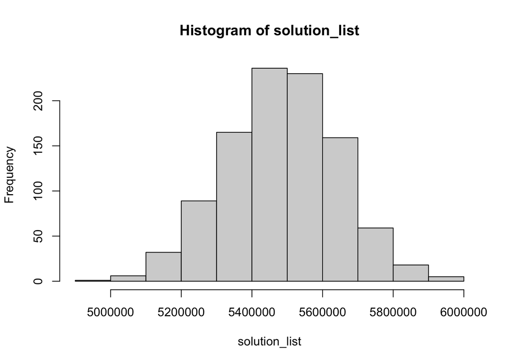

```r
hist(solution_list)
```

```r
summary(solution_list)
```

```
##        V1
##  Min.   :4997720
##  1st Qu.:5376873
##  Median :5489325
##  Mean   :5485087
##  3rd Qu.:5593934
##  Max.   :5942650
```

Adjusting for the random increase/decrease of (-20% to 20%) price, the mean cost of the exhibit is $5,485,087 with a range of $4,997720 to $5,942,650. Comparing the possibility impact (mean cost of exhibit) to Celeste’s proposal 2, we see that proposal 3 will reduce the total cost by $114,913. However, there is a possibility that proposal 2 may be better if the exhibit price of proposal 3 reaches its maximum cost.

## Proposal 4

- Inter-arrival time (lamda): 7 posters/hour
- Service rate (mu): each poster takes an hour to develop = 1 poster/hour
- Number of printer (s): 10 printers
- Number of poster: 7

### Step 1. Get Initial Cost of the Printing Process

```r
# Set up problem with criteria and 10 printers
# n = posters, lam = #print/hour, mu = , s = printers
n <- 7; lam = 7; mu = 1; s = 10

# show costs
print_cost <- 7
inv_cost <- 8

# Build a table of results
print_process <- as.data.frame(matrix(0, n+1, 8))


# Loop to build table of results
for (i in 0:n){

  # Using "queueing" package
  q_mod <- NewInput.MMC(lambda = lam, mu = mu, c = s, n = 10)
  m <- QueueingModel.i_MMC(q_mod)

  #wait costs
  wc <- m$Lq * inv_cost

  # print costs
  pc <- i*print_cost

  # total cost
  tc <- wc + pc

  # Place results as a row in a table
  # do not convert to minutes since we want cost per hour

  print_process[i+1,] <- round(c(i, m$L, m$Lq, m$W, m$Wq, wc/m$W, pc/m$W, tc/m$W), 2)
}

# Add column names
colnames(print_process) <- c("Processes", "L", "Lq", "Process_Time_hrs", "Wait Time (hrs)",
                               "Hourly_Wait_Cost", "Hourly_Process_Cost", "Hourly_Cost")
```

| Processes | L | Lq | Process_Time_hrs | Wait Time (hrs) | Hourly_Wait_Cost | Hourly_Process_Cost | Hourly_Cost |
| --- | --- | --- | --- | --- | --- | --- | --- |
| 0 | 7.52 | 0.52 | 1.07 | 0.07 | 3.85 | 0.00 | 3.85 |
| 1 | 7.52 | 0.52 | 1.07 | 0.07 | 3.85 | 6.52 | 10.37 |
| 2 | 7.52 | 0.52 | 1.07 | 0.07 | 3.85 | 13.04 | 16.89 |
| 3 | 7.52 | 0.52 | 1.07 | 0.07 | 3.85 | 19.55 | 23.41 |
| 4 | 7.52 | 0.52 | 1.07 | 0.07 | 3.85 | 26.07 | 29.93 |
| 5 | 7.52 | 0.52 | 1.07 | 0.07 | 3.85 | 32.59 | 36.45 |
| 6 | 7.52 | 0.52 | 1.07 | 0.07 | 3.85 | 39.11 | 42.96 |
| 7 | 7.52 | 0.52 | 1.07 | 0.07 | 3.85 | 45.63 | 49.48 |

<sup>a</sup> Probability that posters will wait in the queue: 1  
<sup>a</sup> Probability that all printers are busy is: 0.249

### Step 2: Current Cost of Inspecting System

```r
i <- 1
n <- 1
lam <- 7
mu <- 8

inv_cost <- 8

wage <- 17

# Build a table of results
inspect_process <- as.data.frame(matrix(0, n+1, 8))


# Loop to build table of results
for (i in 0:n){

  # Using "queueing" package
  q_mod2 <- NewInput.MM1(lambda = lam, mu = mu)
  m2 <- QueueingModel.i_MM1(q_mod2)

  # Cost of sitting print
  wc <- m2$Lq * inv_cost

  # Cost of inspection
  sc <- i*wage

  # Total cost
  tc <- sc + wc

  # Place results as a row in a table
  inspect_process[i+1,] <- round(c(i, m2$L, m2$Lq, m2$W, m2$Wq, wc/m2$W, sc/m2$W, tc/m2$W), 2)
}

# Add column names
colnames(inspect_process) <- c("Processes", "L", "Lq", "Process_Time_hrs", "Wait Time (hrs)",
                               "Hourly_Wait_Cost", "Hourly_Process_Cost", "Hourly_Cost")
```

| Processes | L | Lq | Process_Time_hrs | Wait Time (hrs) | Hourly_Wait_Cost | Hourly_Process_Cost | Hourly_Cost |
| --- | --- | --- | --- | --- | --- | --- | --- |
| 0 | 7 | 6.12 | 1 | 0.88 | 49 | 0 | 49 |
| 1 | 7 | 6.12 | 1 | 0.88 | 49 | 17 | 66 |

Get the hourly cost of the current state

| Processes | L | Lq | Process_Time_hrs | Wait Time (hrs) | Hourly_Wait_Cost | Hourly_Process_Cost | Hourly_Cost |
| --- | --- | --- | --- | --- | --- | --- | --- |
| 7 | 7.52 | 0.52 | 1.07 | 0.07 | 3.85 | 45.63 | 49.48 |
| 1 | 7.00 | 6.12 | 1.00 | 0.88 | 49.00 | 17.00 | 66.00 |

### 4.

During Printing the expected amount of in-process steady state inventory 7 units. During inspection the expected amount of in-process steady state inventory is 7 units. The estimated cost per hour during printing is $49.48 and the estimated cost per hour of inspecting is $66.

### Proposal 4: Printing Slower and Reducing Power Costs

```r
n <- 7; lam = 7; mu = 1/1.2; s = 10

# show costs
print_cost <- 6.5
inv_cost <- 8

# Build a table of results
print_process2 <- as.data.frame(matrix(0, n+1, 8))


# Loop to build table of results
for (i in 0:n){

  # Using "queueing" package
  q_mod <- NewInput.MMC(lambda = lam, mu = mu, c = s, n = 10)
  m3 <- QueueingModel.i_MMC(q_mod)

  #wait costs
  wc <- m3$Lq * inv_cost

  # print costs
  pc <- i*print_cost

  # total cost
  tc <- wc + pc

  # Place results as a row in a table
  # Multiply wait by 60 minutes in an hour to convert time from hours to minutes
  print_process2[i+1,] <- round(c(i, m3$L, m3$Lq, m3$W, m3$Wq, wc/m3$W, pc/m3$W, tc/m3$W), 2)
}


# Add column names
colnames(print_process2)<- c("Processes", "L", "Lq", "Process_Time_hrs", "Wait Time (hrs)",
                               "Hourly_Wait_Cost", "Hourly_Process_Cost", "Hourly_Cost")
```

| Processes | L | Lq | Process_Time_hrs | Wait Time (hrs) | Hourly_Wait_Cost | Hourly_Process_Cost | Hourly_Cost |
| --- | --- | --- | --- | --- | --- | --- | --- |
| 0 | 11.05 | 2.65 | 1.58 | 0.38 | 13.42 | 0.00 | 13.42 |
| 1 | 11.05 | 2.65 | 1.58 | 0.38 | 13.42 | 4.12 | 17.54 |
| 2 | 11.05 | 2.65 | 1.58 | 0.38 | 13.42 | 8.24 | 21.66 |
| 3 | 11.05 | 2.65 | 1.58 | 0.38 | 13.42 | 12.36 | 25.78 |
| 4 | 11.05 | 2.65 | 1.58 | 0.38 | 13.42 | 16.47 | 29.89 |
| 5 | 11.05 | 2.65 | 1.58 | 0.38 | 13.42 | 20.59 | 34.01 |
| 6 | 11.05 | 2.65 | 1.58 | 0.38 | 13.42 | 24.71 | 38.13 |
| 7 | 11.05 | 2.65 | 1.58 | 0.38 | 13.42 | 28.83 | 42.25 |

| Processes | L | Lq | Process_Time_hrs | Wait Time (hrs) | Hourly_Wait_Cost | Hourly_Process_Cost | Hourly_Cost |
| --- | --- | --- | --- | --- | --- | --- | --- |
| 7 | 11.05 | 2.65 | 1.58 | 0.38 | 13.42 | 28.83 | 42.25 |
| 1 | 7.00 | 6.12 | 1.00 | 0.88 | 49.00 | 17.00 | 66.00 |

### 5.

If printing time is increased to reduce power costs, it will take about a half hour longer to print 7 poster sheets, but the overall cost per hour is reduced by $7.23. In the current printing system the waiting time of posters is minimized, but it is more cost effective to print slower and use less energy than print fast and minimizing waiting time.

```r
# hire a faster and more experienced inspector (proposal 4)
i <- 1
n <- 1
lam <- 7
mu <- 8.57

inv_cost <- 8

wage <- 19

# Build a table of results
inspect_process2 <- as.data.frame(matrix(0, n+1, 8))


# Loop to build table of results
for (i in 0:n){

  # Using "queueing" package
  q_mod2 <- NewInput.MM1(lambda = lam, mu = mu)
  m4 <- QueueingModel.i_MM1(q_mod2)

  # Cost of sitting print
  wc <- m4$Lq * inv_cost

  # Cost of inspection
  sc <- i*wage

  # Total cost
  tc <- sc + wc

# Place results as a row in a table
  inspect_process2[i+1,] <- round(c(i, m4$L, m4$Lq, m4$W, m4$Wq, wc/m4$W, sc/m4$W, tc/m4$W), 2)
}

# Add column names
colnames(inspect_process2) <- c("Processes", "L", "Lq", "Process_Time_hrs", "Wait Time (hrs)",
                               "Hourly_Wait_Cost", "Hourly_Process_Cost", "Hourly_Cost")
```

| Processes | L | Lq | Process_Time_hrs | Wait Time (hrs) | Hourly_Wait_Cost | Hourly_Process_Cost | Hourly_Cost |
| --- | --- | --- | --- | --- | --- | --- | --- |
| 0 | 4.46 | 3.64 | 0.64 | 0.52 | 45.74 | 0.00 | 45.74 |
| 1 | 4.46 | 3.64 | 0.64 | 0.52 | 45.74 | 29.83 | 75.57 |

<sup>a</sup> Probability that posters will wait in the queue: 0.817  
<sup>a</sup> Probability that all printers are busy is: 0.45

```r
last_row4 <- tail(inspect_process2, n = 1)
proposal5 <- bind_rows(last_row1, last_row4)
proposal5
```

| Processes | L | Lq | Process_Time_hrs | Wait Time (hrs) | Hourly_Wait_Cost | Hourly_Process_Cost | Hourly_Cost |
| --- | --- | --- | --- | --- | --- | --- | --- |
| 7 | 7.52 | 0.52 | 1.07 | 0.07 | 3.85 | 45.63 | 49.48 |
| 1 | 4.46 | 3.64 | 0.64 | 0.52 | 45.74 | 29.83 | 75.57 |

Hiring a more experienced inspector will reduce the amount of time it takes to inspect 7 prints by 21.6 minutes. Hiring a more experienced inspector is more cost effective depending on the amount of prints needed and the amount of hours they need to work. The more experienced inspector will cost $9 more per hour.